# Clasificador Naive Bayes aplicado al conjunto de datos Iris

# Introducción

El objetivo de este documento es explicar el fundamento teórico del **Teorema de Bayes** y su aplicación práctica a través del clasificador **Naive Bayes**, para después implementarlo en R usando el paquete `e1071` sobre el conjunto de datos **Iris**.

# 1. Teorema de Bayes

El Teorema de Bayes permite “invertir” una probabilidad condicional. Es decir, si conocemos $P(B \mid A)$, podemos calcular $P(A \mid B)$ mediante:

$$P(A \mid B) = \frac{P(A) \cdot P(B \mid A)}{P(B)}$$

Esta fórmula se deriva de la definición de probabilidad condicional:

$$P(A \mid B) = \frac{P(A \cap B)}{P(B)}, \qquad P(A \cap B) = P(A \mid B)
\cdot P(B)$$

Este resultado es la base de la clasificación bayesiana: nos permite calcular la probabilidad de que un registro pertenezca a una clase $c$, dado que observamos ciertas características (evidencia).

# 2. Del Teorema de Bayes al clasificador Naive Bayes

Un **clasificador Naive Bayes** es un método de aprendizaje supervisado que, dado un conjunto de características $x_1, x_2, \dots, x_n$, determina cuál es la clase $c$ más probable a la que pertenece un registro. Partiendo del Teorema de Bayes:

$$P(c \mid x_1, \dots, x_n) = \frac{P(c) \cdot P(x_1, \dots, x_n \mid
c)}{P(x_1, \dots, x_n)}$$

El término $P(x_1, \dots, x_n \mid c)$ es difícil de estimar directamente, porque implicaría conocer la distribución conjunta de todos los atributos. Aquí es donde entra el supuesto **“ingenuo” (naive)** de independencia condicional: se asume que, dado el valor de la clase, los atributos son independientes entre sí:

$$P(x_1, \dots, x_n \mid c) = P(x_1 \mid c) \cdot P(x_2 \mid c) \cdots
P(x_n \mid c)$$

Sustituyendo:

$$P(c \mid x_1, \dots, x_n) = \frac{P(c) \cdot \prod_{i=1}^{n} P(x_i \mid
c)}{P(x_1, \dots, x_n)}$$

Como el denominador $P(x_1, \dots, x_n)$ es el mismo para todas las clases que se comparan (no depende de $c$), no afecta la comparación relativa entre clases y se puede eliminar. Esto da la fórmula final que usa el algoritmo:

$$P(c \mid x_1, \dots, x_n) \;\propto\; P(c) \cdot \prod_{i=1}^{n} P(x_i
\mid c)$$

**Algoritmo:**

1. Para cada clase $c_j$, calcular $P(c_j) \cdot \prod_{i=1}^{n} P(x_i \mid c_j)$.
2. Seleccionar la clase con la mayor probabilidad resultante.

## 2.1 Estimación de probabilidades

- **$P(c)$ (probabilidad a priori):** se estima como la frecuencia relativa de cada clase en el conjunto de entrenamiento: $P(c) = n_c / N$.
- **$P(x_i \mid c)$ (verosimilitud):**
  - Si los atributos son **discretos**, se estima contando frecuencias (como en el ejemplo clásico de “jugar” según ambiente, temperatura y viento).
  - Si los atributos son **continuos** (como en el caso de **Iris**), se supone que cada atributo se distribuye según una **normal**:

$$x_i \mid c \sim N\left(\mu_i^c, (\sigma_i^c)^2\right)$$

y se utiliza la función de densidad gaussiana:

$$P(x_i \mid c) = \frac{1}{\sqrt{2\pi}\,\sigma_i^c}
\exp\left(-\frac{(x_i - \mu_i^c)^2}{2(\sigma_i^c)^2}\right)$$

Es este segundo caso (atributos continuos con distribución normal) el que aplica directamente al conjunto de datos Iris, ya que sus predictores (largo y ancho de sépalo y pétalo) son variables numéricas continuas.

## 2.2 Nota sobre el uso de logaritmos

Cuando se multiplican muchas probabilidades (valores entre 0 y 1), el producto puede volverse extremadamente pequeño y producir *underflow* numérico. Por ello, en la práctica es común aplicar logaritmos:

$$\text{Clase predicha} = \arg\max_{c_j}\left[\log P(c_j) + \sum_{i=1}^{n}
\log P(x_i \mid c_j)\right]$$

El paquete `e1071` maneja estos detalles internamente, por lo que no es necesario implementarlos manualmente.

# 3. El conjunto de datos Iris

El dataset `iris`, incluido en R, contiene 150 observaciones de flores del género Iris, con 4 atributos numéricos continuos (`Sepal.Length`, `Sepal.Width`, `Petal.Length`, `Petal.Width`) y una variable de clase `Species` con tres niveles: *setosa*, *versicolor* y *virginica*.

```r
data(iris)
str(iris)
```

```
## 'data.frame':    150 obs. of  5 variables:
##  $ Sepal.Length: num  5.1 4.9 4.7 4.6 5 5.4 4.6 5 4.4 4.9 ...
##  $ Sepal.Width : num  3.5 3 3.2 3.1 3.6 3.9 3.4 3.4 2.9 3.1 ...
##  $ Petal.Length: num  1.4 1.4 1.3 1.5 1.4 1.7 1.4 1.5 1.4 1.5 ...
##  $ Petal.Width : num  0.2 0.2 0.2 0.2 0.2 0.4 0.3 0.2 0.2 0.1 ...
##  $ Species     : Factor w/ 3 levels "setosa","versicolor",..: 1 1 1 1 1 1 1 1 1 1 ...
```

```r
summary(iris)
```

```
##   Sepal.Length    Sepal.Width     Petal.Length    Petal.Width
##  Min.   :4.300   Min.   :2.000   Min.   :1.000   Min.   :0.100
##  1st Qu.:5.100   1st Qu.:2.800   1st Qu.:1.600   1st Qu.:0.300
##  Median :5.800   Median :3.000   Median :4.350   Median :1.300
##  Mean   :5.843   Mean   :3.057   Mean   :3.758   Mean   :1.199
##  3rd Qu.:6.400   3rd Qu.:3.300   3rd Qu.:5.100   3rd Qu.:1.800
##  Max.   :7.900   Max.   :4.400   Max.   :6.900   Max.   :2.500
##        Species
##  setosa    :50
##  versicolor:50
##  virginica :50
##
##
##
```

Dado que los predictores son continuos, Naive Bayes estimará, para cada especie, la media y desviación estándar de cada atributo, y usará la densidad normal para calcular $P(x_i \mid c)$.

# 4. Implementación en R con el paquete `e1071`

## 4.1 Carga de paquetes

```r
library(e1071)    # Contiene la función naiveBayes()
library(caret)    # Para partición de datos y evaluación del modelo
library(ggplot2)  # Para visualización
```

## 4.2 División en entrenamiento y prueba

Se utiliza una semilla fija para que la partición sea reproducible, y se separa el 70% de los datos para entrenamiento y 30% para prueba, manteniendo la proporción de clases mediante `createDataPartition`.

```r
set.seed(123)

train_index <- createDataPartition(iris$Species, p = 0.7, list = FALSE)

train_data <- iris[train_index, ]   # filas de entrenamiento
test_data  <- iris[-train_index, ]  # filas de prueba

dim(train_data)
```

```
## [1] 105   5
```

```r
dim(test_data)
```

```
## [1] 45  5
```

## 4.3 Entrenamiento del modelo

La fórmula `Species ~ .` indica que se quiere predecir `Species` usando todas las demás variables del data frame como predictores. Internamente, `naiveBayes()` calcula, para cada clase, la media y desviación estándar de cada atributo continuo (los parámetros de la normal $N(\mu_i^c, (\sigma_i^c)^2)$) y las probabilidades a priori $P(c)$.

```r
modelo_nb <- naiveBayes(Species ~ ., data = train_data)
modelo_nb
```

```
##
## Naive Bayes Classifier for Discrete Predictors
##
## Call:
## naiveBayes.default(x = X, y = Y, laplace = laplace)
##
## A-priori probabilities:
## Y
##     setosa versicolor  virginica
##  0.3333333  0.3333333  0.3333333
##
## Conditional probabilities:
##             Sepal.Length
## Y                [,1]      [,2]
##   setosa     4.991429 0.3657156
##   versicolor 5.942857 0.4558674
##   virginica  6.631429 0.6846087
##
##             Sepal.Width
## Y                [,1]      [,2]
##   setosa     3.365714 0.3455114
##   versicolor 2.777143 0.3227508
##   virginica  2.982857 0.3222035
##
##             Petal.Length
## Y                [,1]      [,2]
##   setosa     1.471429 0.1808012
##   versicolor 4.262857 0.4222389
##   virginica  5.591429 0.5741344
##
##             Petal.Width
## Y                 [,1]       [,2]
##   setosa     0.2314286 0.09321521
##   versicolor 1.3285714 0.20518489
##   virginica  2.0342857 0.25775371
```

## 4.4 Predicciones sobre el conjunto de prueba

```r
predicciones <- predict(modelo_nb, test_data)
predicciones
```

```
##  [1] setosa     setosa     setosa     setosa     setosa     setosa
##  [7] setosa     setosa     setosa     setosa     setosa     setosa
## [13] setosa     setosa     setosa     versicolor virginica  versicolor
## [19] versicolor versicolor versicolor virginica  versicolor versicolor
## [25] versicolor versicolor versicolor versicolor versicolor versicolor
## [31] virginica  virginica  virginica  virginica  virginica  virginica
## [37] versicolor virginica  virginica  virginica  versicolor virginica
## [43] virginica  virginica  virginica
## Levels: setosa versicolor virginica
```

Comparamos las predicciones contra los valores reales:

```r
test_data$Species
```

```
##  [1] setosa     setosa     setosa     setosa     setosa     setosa
##  [7] setosa     setosa     setosa     setosa     setosa     setosa
## [13] setosa     setosa     setosa     versicolor versicolor versicolor
## [19] versicolor versicolor versicolor versicolor versicolor versicolor
## [25] versicolor versicolor versicolor versicolor versicolor versicolor
## [31] virginica  virginica  virginica  virginica  virginica  virginica
## [37] virginica  virginica  virginica  virginica  virginica  virginica
## [43] virginica  virginica  virginica
## Levels: setosa versicolor virginica
```

## 4.5 Evaluación del modelo

Usamos una matriz de confusión con `caret::confusionMatrix` para medir el desempeño del modelo (exactitud, sensibilidad, especificidad por clase, etc.).

```r
matriz_confusion <- confusionMatrix(predicciones, test_data$Species)
matriz_confusion
```

```
## Confusion Matrix and Statistics
##
##             Reference
## Prediction   setosa versicolor virginica
##   setosa         15          0         0
##   versicolor      0         13         2
##   virginica       0          2        13
##
## Overall Statistics
##
##                Accuracy : 0.9111
##                  95% CI : (0.7878, 0.9752)
##     No Information Rate : 0.3333
##     P-Value [Acc > NIR] : 8.467e-16
##
##                   Kappa : 0.8667
##
##  Mcnemar's Test P-Value : NA
##
## Statistics by Class:
##
##                      Class: setosa Class: versicolor Class: virginica
## Sensitivity                 1.0000            0.8667           0.8667
## Specificity                 1.0000            0.9333           0.9333
## Pos Pred Value              1.0000            0.8667           0.8667
## Neg Pred Value              1.0000            0.9333           0.9333
## Prevalence                  0.3333            0.3333           0.3333
## Detection Rate              0.3333            0.2889           0.2889
## Detection Prevalence        0.3333            0.3333           0.3333
## Balanced Accuracy           1.0000            0.9000           0.9000
```

## 4.6 Predicción sobre nuevas observaciones

Al igual que en el ejemplo de “jugar” (donde se calculaba $P(c_j \mid x_1,\dots,x_n)$ para nuevas combinaciones de ambiente, temperatura y viento), aquí calculamos la clase más probable para tres nuevas flores hipotéticas, dados sus valores de sépalo y pétalo.

```r
nuevos_datos <- data.frame(
  Sepal.Length = c(5.1, 6.7, 5.8),
  Sepal.Width  = c(3.5, 3.0, 2.7),
  Petal.Length = c(1.4, 5.2, 4.2),
  Petal.Width  = c(0.2, 2.3, 1.3)
)
nuevos_datos
```

```
##   Sepal.Length Sepal.Width Petal.Length Petal.Width
## 1          5.1         3.5          1.4         0.2
## 2          6.7         3.0          5.2         2.3
## 3          5.8         2.7          4.2         1.3
```

```r
nuevas_predicciones <- predict(modelo_nb, nuevos_datos)
nuevas_predicciones
```

```
## [1] setosa     virginica  versicolor
## Levels: setosa versicolor virginica
```

```r
probabilidades <- predict(modelo_nb, nuevos_datos, type = "raw")
probabilidades
```

```
##             setosa   versicolor    virginica
## [1,]  1.000000e+00 8.913737e-20 5.114392e-26
## [2,] 1.785606e-203 1.268812e-06 9.999987e-01
## [3,]  9.123989e-80 9.998715e-01 1.285303e-04
```

## 4.7 Visualización de los datos

Para entender mejor por qué el modelo separa bien las especies, es útil visualizar la relación entre dos de los atributos más discriminantes: `Petal.Length` y `Petal.Width`.

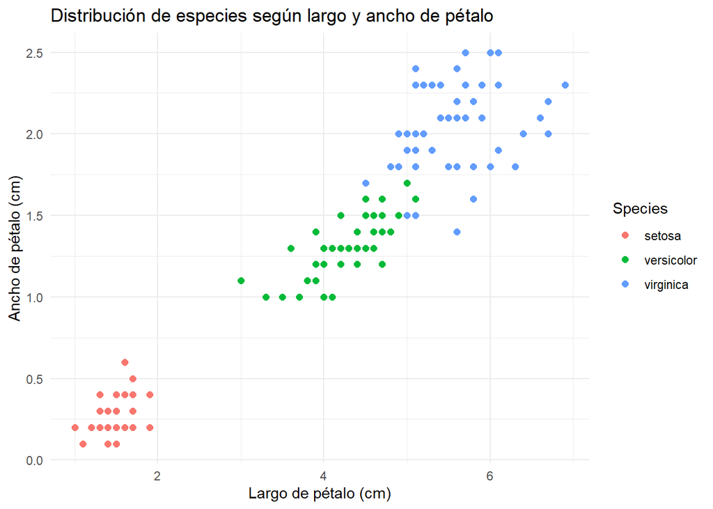

```r
ggplot(iris, aes(x = Petal.Length, y = Petal.Width, color = Species)) +
  geom_point(size = 2) +
  labs(
    title = "Distribución de especies según largo y ancho de pétalo",
    x = "Largo de pétalo (cm)",
    y = "Ancho de pétalo (cm)"
  ) +
  theme_minimal()
```

Se observa que las tres especies forman agrupaciones relativamente separadas, lo cual explica por qué el supuesto de normalidad por clase que usa Naive Bayes funciona bien en este conjunto de datos.

# 5. Conclusiones

El clasificador Naive Bayes aplica directamente el Teorema de Bayes, asumiendo independencia condicional entre los atributos dada la clase. Para atributos discretos se estiman frecuencias; para atributos continuos, como los de Iris, se asume una distribución normal por clase y atributo. El paquete `e1071` en R automatiza el cálculo de las probabilidades a priori, las medias y desviaciones estándar por clase, y la predicción final mediante `predict()`. Sobre el conjunto de datos Iris, el modelo logra una alta exactitud debido a la buena separación entre especies, especialmente al usar `Petal.Length` y `Petal.Width`.